# project 1

```python
#import all the library required for doing the project
import numpy as np
import pandas as pd
import matplotlib.pyplot as plt
import seaborn as sns
sns.set(color_codes=True)
%matplotlib inline
```

```python
#Load data set which is in csv file  into "data variable"
data=pd.read_csv('CardioGoodFitness.csv')
```

```python
data.shape # The data shape gives number of rows and columns in data.
#From output below we have 180 rows and 9 columns
```

```
(180, 9)
```

```python
data.dtypes
#Above code tells us data type. We have 3 categorical variables and 6 Quantitative integer variables
```

```
Product          object
Age               int64
Gender           object
Education         int64
MaritalStatus    object
Usage             int64
Fitness           int64
Income            int64
Miles             int64
dtype: object
```

```python
#sample 20 top rows of data
data.head(20)
```

|  | Product | Age | Gender | Education | MaritalStatus | Usage | Fitness | Income | Miles |
| --- | --- | --- | --- | --- | --- | --- | --- | --- | --- |
| 0 | TM195 | 18 | Male | 14 | Single | 3 | 4 | 29562 | 112 |
| 1 | TM195 | 19 | Male | 15 | Single | 2 | 3 | 31836 | 75 |
| 2 | TM195 | 19 | Female | 14 | Partnered | 4 | 3 | 30699 | 66 |
| 3 | TM195 | 19 | Male | 12 | Single | 3 | 3 | 32973 | 85 |
| 4 | TM195 | 20 | Male | 13 | Partnered | 4 | 2 | 35247 | 47 |
| 5 | TM195 | 20 | Female | 14 | Partnered | 3 | 3 | 32973 | 66 |
| 6 | TM195 | 21 | Female | 14 | Partnered | 3 | 3 | 35247 | 75 |
| 7 | TM195 | 21 | Male | 13 | Single | 3 | 3 | 32973 | 85 |
| 8 | TM195 | 21 | Male | 15 | Single | 5 | 4 | 35247 | 141 |
| 9 | TM195 | 21 | Female | 15 | Partnered | 2 | 3 | 37521 | 85 |
| 10 | TM195 | 22 | Male | 14 | Single | 3 | 3 | 36384 | 85 |
| 11 | TM195 | 22 | Female | 14 | Partnered | 3 | 2 | 35247 | 66 |
| 12 | TM195 | 22 | Female | 16 | Single | 4 | 3 | 36384 | 75 |
| 13 | TM195 | 22 | Female | 14 | Single | 3 | 3 | 35247 | 75 |
| 14 | TM195 | 23 | Male | 16 | Partnered | 3 | 1 | 38658 | 47 |
| 15 | TM195 | 23 | Male | 16 | Partnered | 3 | 3 | 40932 | 75 |
| 16 | TM195 | 23 | Female | 14 | Single | 2 | 3 | 34110 | 103 |
| 17 | TM195 | 23 | Male | 16 | Partnered | 4 | 3 | 39795 | 94 |
| 18 | TM195 | 23 | Female | 16 | Single | 4 | 3 | 38658 | 113 |
| 19 | TM195 | 23 | Female | 15 | Partnered | 2 | 2 | 34110 | 38 |

```python
#sample bottom 20 rows of data
data.tail(10)
```

|  | Product | Age | Gender | Education | MaritalStatus | Usage | Fitness | Income | Miles |
| --- | --- | --- | --- | --- | --- | --- | --- | --- | --- |
| 170 | TM798 | 31 | Male | 16 | Partnered | 6 | 5 | 89641 | 260 |
| 171 | TM798 | 33 | Female | 18 | Partnered | 4 | 5 | 95866 | 200 |
| 172 | TM798 | 34 | Male | 16 | Single | 5 | 5 | 92131 | 150 |
| 173 | TM798 | 35 | Male | 16 | Partnered | 4 | 5 | 92131 | 360 |
| 174 | TM798 | 38 | Male | 18 | Partnered | 5 | 5 | 104581 | 150 |
| 175 | TM798 | 40 | Male | 21 | Single | 6 | 5 | 83416 | 200 |
| 176 | TM798 | 42 | Male | 18 | Single | 5 | 4 | 89641 | 200 |
| 177 | TM798 | 45 | Male | 16 | Single | 5 | 5 | 90886 | 160 |
| 178 | TM798 | 47 | Male | 18 | Partnered | 4 | 5 | 104581 | 120 |
| 179 | TM798 | 48 | Male | 18 | Partnered | 4 | 5 | 95508 | 180 |

```python
#Describe helps us to get brief summary of each variable
data.describe()
```

|  | Age | Education | Usage | Fitness | Income | Miles |
| --- | --- | --- | --- | --- | --- | --- |
| count | 180.000000 | 180.000000 | 180.000000 | 180.000000 | 180.000000 | 180.000000 |
| mean | 28.788889 | 15.572222 | 3.455556 | 3.311111 | 53719.577778 | 103.194444 |
| std | 6.943498 | 1.617055 | 1.084797 | 0.958869 | 16506.684226 | 51.863605 |
| min | 18.000000 | 12.000000 | 2.000000 | 1.000000 | 29562.000000 | 21.000000 |
| 25% | 24.000000 | 14.000000 | 3.000000 | 3.000000 | 44058.750000 | 66.000000 |
| 50% | 26.000000 | 16.000000 | 3.000000 | 3.000000 | 50596.500000 | 94.000000 |
| 75% | 33.000000 | 16.000000 | 4.000000 | 4.000000 | 58668.000000 | 114.750000 |
| max | 50.000000 | 21.000000 | 7.000000 | 5.000000 | 104581.000000 | 360.000000 |

## Describe code helps us to understand the spread of 6 quantitative variables

### Usage variable:Mean is almost equal to median so we should have normal distribution and extreme light skew towards right

### Fitness variable:Mean is almost equal to median so we should have normal distribution and extreme light skew towards right

### Income variable:Mean is slightly greater than median so we have right skew

### Miles variable:Mean is slightly greater than median so we have right skew

```python
#Code to check if we have any missing data across variables
data.isnull().sum().sort_values(ascending=False)
```

```
Miles            0
Income           0
Fitness          0
Usage            0
MaritalStatus    0
Education        0
Gender           0
Age              0
Product          0
dtype: int64
```

## We have no missing values across all the 9 variables

# Univariate Analysis

### We Will first complete Univariate analysis of all categorical variables and then univariate analysis of Quantitative variables

```python
#The code below helps to count across gender
data.groupby(by=['Gender']).count()
```

| Gender | Product | Age | Education | MaritalStatus | Usage | Fitness | Income | Miles |
| --- | --- | --- | --- | --- | --- | --- | --- | --- |
| Female | 76 | 76 | 76 | 76 | 76 | 76 | 76 | 76 |
| Male | 104 | 104 | 104 | 104 | 104 | 104 | 104 | 104 |

## We have more male customers with 57.78% being male.

```python
#The code below helps to count across product
data.groupby(by=['Product']).count()
```

| Product | Age | Gender | Education | MaritalStatus | Usage | Fitness | Income | Miles |
| --- | --- | --- | --- | --- | --- | --- | --- | --- |
| TM195 | 80 | 80 | 80 | 80 | 80 | 80 | 80 | 80 |
| TM498 | 60 | 60 | 60 | 60 | 60 | 60 | 60 | 60 |
| TM798 | 40 | 40 | 40 | 40 | 40 | 40 | 40 | 40 |

### 44.44% of sales were from TM 195

### 33.33% of sales were from TM 498

### 22.22% of sales were from TM 798

```python
#The code below helps to count across Marital status
data.groupby(by=['MaritalStatus'])['Product'].count()
```

```
MaritalStatus
Partnered    107
Single        73
Name: Product, dtype: int64
```

### 59.44% of sales were by partnered

### 40.56% of sales were by single

### Let us Graphically take a look at categorical variables that we just analysed above

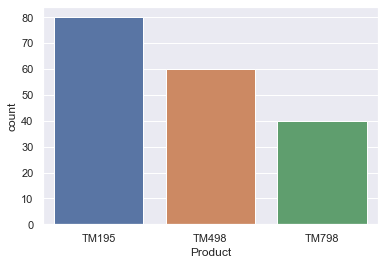

```python
sns.countplot(data['Product'])
```

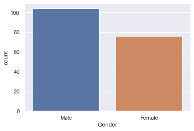

```python
sns.countplot(data['Gender'])
```

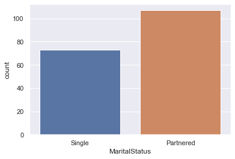

```python
sns.countplot(data['MaritalStatus'])
```

## We will do univariate analysis across Quantitative variables below

### We will plot histogram and bloxplot across variable age

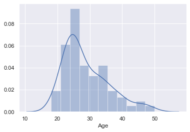

```python
sns.distplot(data['Age'])
```

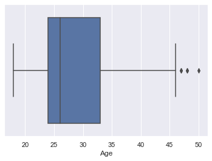

```python
sns.boxplot(data['Age'])
```

### 50% of sales were in age group of 24 and 33

### All the sales were in age group of 10 to 50 years

### Slaes of product by AGE were slightly right skewed with few outliers beyond right whisker of 46 years age

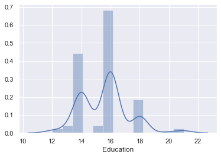

```python
sns.distplot(data['Education'])
```

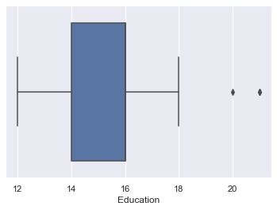

```python
sns.boxplot(data['Education'])
```

### 50% of sales were in education group of 14 and 16

### All the sales were in education group of 12 to 18 years with few outliers beyond 18 years

### Data by Educations looks normally distributed

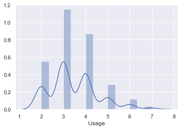

```python
sns.distplot(data['Usage'])
```

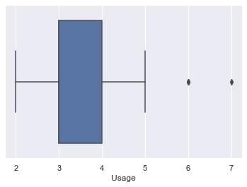

```python
sns.boxplot(data['Usage'])
```

### 50% of sales were in usage group of 3 and 4

### All the sales were in usage group of 2 to 5 with few outliers beyond

### Data by usage looks normally distributed

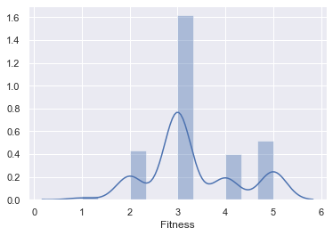

```python
sns.distplot(data['Fitness'])
```

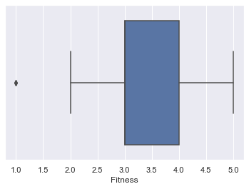

```python
sns.boxplot(data['Fitness'])
```

### 50% of sales were in fitness group of 3.0 and 4.0

### All the sales were in fitness group of 2 to 5 with few outliers below 2 fitness

### Data by fitness looks normally distributed from boxplot

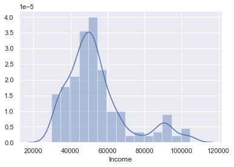

```python
sns.distplot(data['Income'])
```

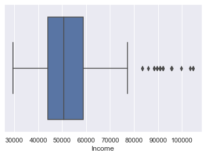

```python
sns.boxplot(data['Income'])
```

### Data by Income looks normally distributed from boxplot and slight right skewed with outliers

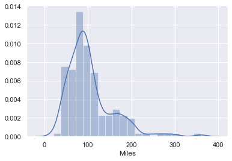

```python
sns.distplot(data['Miles'])
```

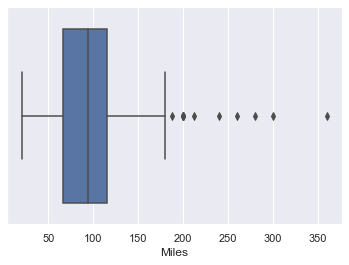

```python
sns.boxplot(data['Miles'])
```

### Data by Miles looks slight right skewed with outliers

# Multivariate Analysis

## We Will first complete Multivariate analysis of all quantitative variables and then bivariate analysis of Quantitative vs Qualitative variables

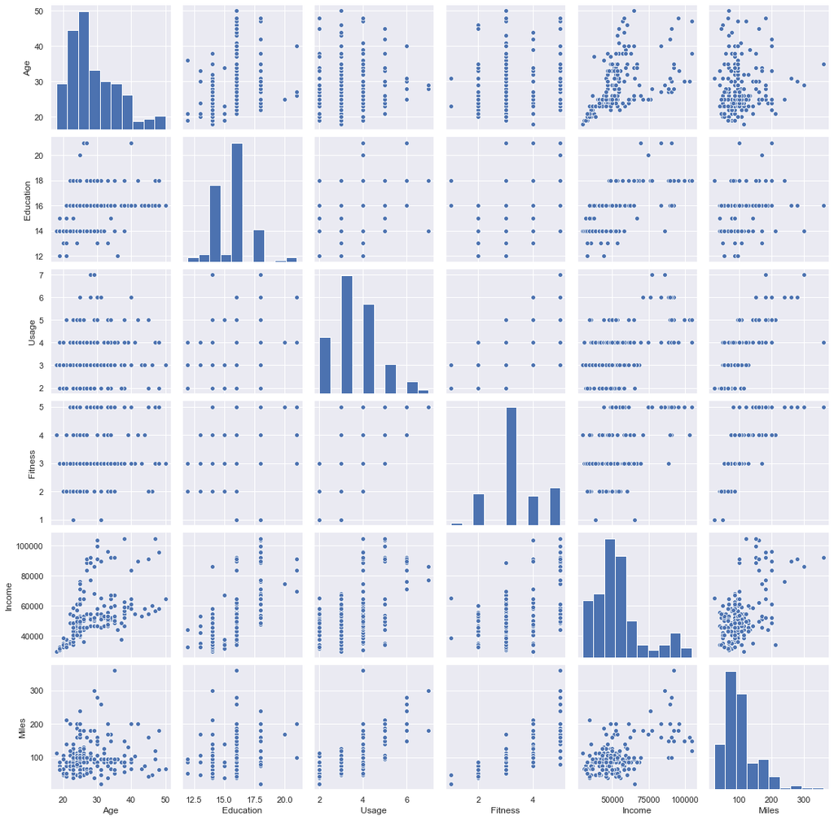

```python
#We will plot scatterplot of all quantitative variables across one another
sns.pairplot(data)
```

### from above scatter The bivariate analysis of 1. Miles vs Age 2. Age vs Income and 3. Miles vs Income will be good to look deeper and we can try fitting regression model

```python
#Let us check correlation across quantitaive variables
data.corr()
```

|  | Age | Education | Usage | Fitness | Income | Miles |
| --- | --- | --- | --- | --- | --- | --- |
| Age | 1.000000 | 0.280496 | 0.015064 | 0.061105 | 0.513414 | 0.036618 |
| Education | 0.280496 | 1.000000 | 0.395155 | 0.410581 | 0.625827 | 0.307284 |
| Usage | 0.015064 | 0.395155 | 1.000000 | 0.668606 | 0.519537 | 0.759130 |
| Fitness | 0.061105 | 0.410581 | 0.668606 | 1.000000 | 0.535005 | 0.785702 |
| Income | 0.513414 | 0.625827 | 0.519537 | 0.535005 | 1.000000 | 0.543473 |
| Miles | 0.036618 | 0.307284 | 0.759130 | 0.785702 | 0.543473 | 1.000000 |

### Miles vs Usage or fitness have slightly high correlation and no negative correlation

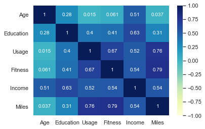

```python
# code to draw heat map across correlation
sns.heatmap(data.corr(), annot=True, cmap='YlGnBu', vmin=-1, vmax=1)
```

### Miles vs fitness have slightly high correlation and no negative correlation

### Miles vs usage have slightly high correlation and no negative correlation

### Income vs education have slightly high correlation and we have no negative correlation

## We Will do Multivariate analysis across various Quantitative and Qualitative variables below

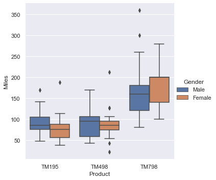

```python
# The below code will help us look into multiple qualitative variables vs quantitative variable
sns.catplot(x="Product",
               y = "Miles",
               hue="Gender",
               data=data,
               kind="box");
```

## Few insights from above fig

### Females across TM 498 had small range and majority of them had miles in range of 75 to 95 miles. However males put little more mile on average in TM498 and had more range

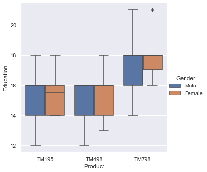

```python
sns.catplot(x="Product",  # catplot function is good when we have to compare more than 1 categorical variable
               y = "Education",
               hue="Gender",
               data=data,
               kind="box");
```

## Few insights from above fig

### People with education level 16 to 18 tend to buy TM798

### People with education level 14 to 16 tend to buy TM195 or TM498

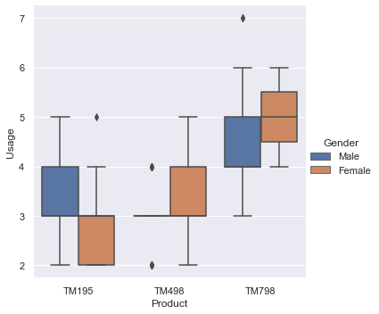

```python
sns.catplot(x="Product",
               y = "Usage",
               hue="Gender",
               data=data,
               kind="box");
```

## Few insights from above fig

### Males with usage level 4 to 5 and females with 4.5 to 5.5 tend to buy TM798

### Males with usage level 3 to 4 tend to buy TM195

### Males with usage level exactly 3 tend to buy TM498

### Females with usage level 3 to 4 tend to buy TM498

### Females with usage level less than 3 tend to buy TM195

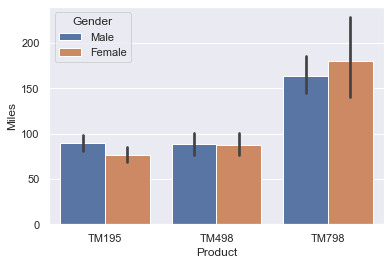

```python
sns.barplot(x=data['Product'],y=data['Miles'], hue= data['Gender'])
```

### TM798 users had significantly high miles(greater than 125) with slightly higher range in females

### TM195 and TM498 users had miles less than 100 across male and female

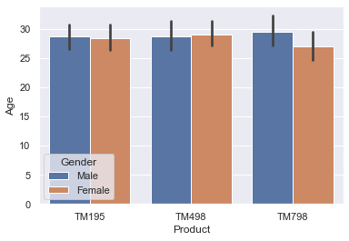

```python
sns.barplot(x=data['Product'],y=data['Age'], hue= data['Gender'])
```

### Slightly younger women tend to buy TM798 .

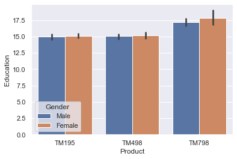

```python
sns.barplot(x=data['Product'],y=data['Education'], hue= data['Gender'])
```

### TM798 users tend to have higher education level. With education level usually greater than 17

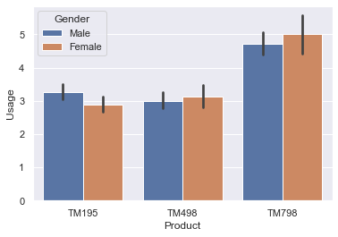

```python
sns.barplot(x=data['Product'],y=data['Usage'], hue= data['Gender']) # barplot is goood when we want to analyse across more than one quantitative variable
```

### TM 798 has little more range across usage in females

### TM 798 has more usage levels in males and females compared to TM195 and TM498

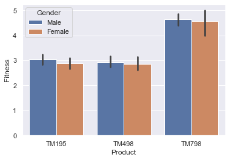

```python
sns.barplot(x=data['Product'],y=data['Fitness'], hue= data['Gender'])
```

### TM 798 has little more range across Fitness in females

### TM 798 users had more fitness level in males and females compared to TM195 and TM498

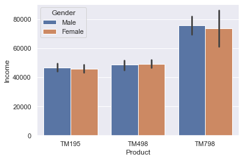

```python
sns.barplot(x=data['Product'],y=data['Income'], hue= data['Gender'])
```

### TM 798 was bought by high income males and females with income level greater than 60000

### TM195 and TM498 was bought by males and females with income level less than 50000

### TM498 users had average income more than TM195

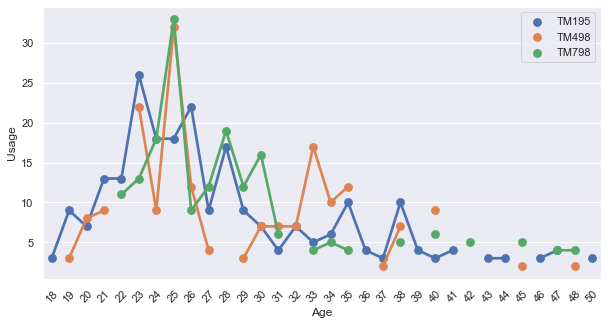

```python
plt.figure(figsize = (10,5)) # To resize the plot
sns.pointplot(x='Age', y='Usage', data=data, estimator=sum, ci=None, hue = 'Product')
plt.legend(bbox_to_anchor=(1, 1))
plt.xticks(rotation=45) # To rotate the x axis labls
```

### The Usage was high in age group 22 to 27 and later it starts declining across various products

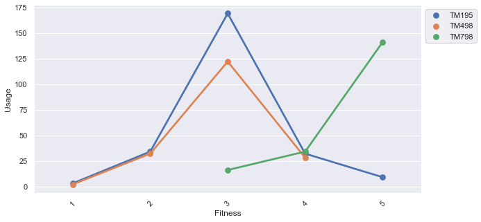

```python
plt.figure(figsize = (10,5)) # To resize the plot
sns.pointplot(x='Fitness', y='Usage', data=data, estimator=sum, ci=None, hue = 'Product')
plt.legend(bbox_to_anchor=(1, 1))
plt.xticks(rotation=45) # To rotate the x axis labls
```

### The Usage vs fitness had same trend from 1 to 4 level in TM195 and TM498

### With increase in ftness usage increased in case of TM7798

## Pandas has inbuilt function to do summarised data analysis

```python
#Importing libraries required for Pandas profiling
import sys
sys.executable
!{sys.executable} -m pip install pandas-profiling
```

```python
#Pandas profiling
import pandas_profiling
pandas_profiling.ProfileReport(data)
```

[interactive chart not shown]